# PARAMO pipeline

# STEP 3. Linking anatomical characters with ontology

Having initial characters code into anatomical ones, let’s now link the charcter with ontology

Hymenoptera Anatomy Ontology [HAO](http://portal.hymao.org/projects/32/public/ontology/)

Let’s read annotations and display them as a table.

```r
AN<-read.csv(file="STEP_3/Char_annotation.csv", header = T, as.is=T, check.names=F)
AN
```

| CHAR_ID | CHAR_ID2 | CHAR* | CHAR_STATEMENT | HAO_ID | HAO_ID_NAME |
| --- | --- | --- | --- | --- | --- |
| C1 | 1 | 3 | Notch on medial margin of eye | HAO:0000234 | cranium |
| C3,2 | 3,2 | 25, 23 | Labrum + Position of labrum | HAO:0000639 | mouthparts |
| C4 | 4 | 353 | Forewing costal and radial vein fusion | HAO:0000351 | fore wing |
| C5,6 | 5,6 | 363 | Hind wing subcostal SC vein, present | HAO:0000400 | hind wing |
| C7 | 7 | 380 | Inner posterior mesotibial spur | HAO:0001351 | mesotibia |
| C8 | 8 | 381 | Foretibial apical sensillum | HAO:0000350 | fore tibia |
| C9 | 9 | 382 | Metatibial apical sensillum | HAO:0000631 | metatibia |

Our goal is to assess the anatomical evolution at three levels of resolution. (1) The first level are 7 elemntary anatomical characters obtained at the previous step. (2) The second level deals with three chracters - “head”, “wings” and “legs” - corresponding to the main body parts. (3) The third level corresponds to the enitre organismal phenotype. We construct the characters for the level 2 and 3 by quering the elementary anatomical characters using HAO and amalgamting their stochastic maps. To query HAO, we use `ontologyIndex` package and a set of preccoked `R` functions located in `PARAMO_functions.R`. Let see how it works.

```r
library("ontologyIndex")
source("R_PARAMO/PARAMO_functions.R")
# opening HAO file, "BFO:0000050" is part_of relatinship
ONT<-get_OBO("STEP_3/HAO.obo", extract_tags="everything", propagate_relationships = c("BFO:0000050", "is_a"))
# let's create  list of anotation from the annotation table
char_id<-paste0("CHAR:", AN$CHAR_ID2)
annot<-set_names(table2list(AN[,c(2,5)]), char_id)
annot
```

```
$`CHAR:1`
[1] "HAO:0000234"

$`CHAR:3,2`
[1] "HAO:0000639"

$`CHAR:4`
[1] "HAO:0000351"

$`CHAR:5,6`
[1] "HAO:0000400"

$`CHAR:7`
[1] "HAO:0001351"

$`CHAR:8`
[1] "HAO:0000350"

$`CHAR:9`
[1] "HAO:0000631"
```

```r
# next we make the annotations to be the part of the ontology object ONT
ONT$terms_selected_id<-annot
```

```r
level2<-set_names(c("HAO:0000397", "HAO:0001089", "HAO:0000494"), c("head", "wings", "legs") )
level3<-set_names(c("HAO:0000012"), c("whole_organism") )
# we use get_descendants_chars to get the set of all anatomcal characters that descend from a particular HAO term, for example:
#get_descendants_chars(ONT, annotations="manual", terms="HAO:0000012")
# now we can query all characters for the level 2 and 3 using the Ontology
L2<-lapply(level2, function(x)
  get_descendants_chars(ONT, annotations="manual", terms=x)  )
"Level 2"
```

```
[1] "Level 2"
```

```r
L2
```

```
$head
[1] "CHAR:1"   "CHAR:3,2"

$wings
[1] "CHAR:4"   "CHAR:5,6"

$legs
[1] "CHAR:7" "CHAR:8" "CHAR:9"
```

```r
L3<-lapply(level3, function(x)
  get_descendants_chars(ONT, annotations="manual", terms=x)  )
"Level 3"
```

```
[1] "Level 3"
```

```r
L3
```

```
$whole_organism
[1] "CHAR:1"   "CHAR:3,2" "CHAR:4"   "CHAR:5,6" "CHAR:7"   "CHAR:8"   "CHAR:9"
```

# STEP 4. Inference: linking characters with models and tree

At this step, we need to construct data files for analysing the set of our seven anatomical characters using RevBayes. Three files have to be created for each character: (1) chraracter file, (2) RevBayes script, and (3) tree file that is shared accross all chracters. The process of file cretion can be automitized using the following scripts.

```r
# reading chracter matrix
MT<-read.csv("STEP_4/matrix.csv", header = T, row.names=1, as.is=T, check.names=F)

# creating chracter files using the matrix
#setwd("~/Documents/Recon-Anc_Anat/Supplementary_materials/STEP_4/RevBayes/data")
for (i in 1:ncol(MT))
{
  C.rev<-MT[,i]
  C.rev<-gsub("&", " ", C.rev)

  out<-cbind(rownames(MT), C.rev)
  write.table(file=paste0(colnames(MT[i]), ".char"), out, quote=F, sep=" ",
              row.names=F, col.names=F)
}

# write Rev file for the two-state characters
setwd("~/Documents/Recon-Anc_Anat/Supplementary_materials/STEP_4/RevBayes/")

# For constructing .Rev files we use the procooked template "PARAMO2_templ.Rev"
fl.in  <- readLines("PARAMO2_templ.Rev")

for (i in 1:ncol(MT))
{
  fl.in  <- readLines("PARAMO2_templ.Rev")
  fl.in  <- gsub(pattern = "@analysis_name@", replace = paste0(colnames(MT[i])),
                 x = fl.in)
  fl.in <- gsub(pattern = "@chrs_2_read@", replace = paste0("data/", colnames(MT[i]), ".char"), x = fl.in)

  cat(file=paste0(colnames(MT[i]), ".Rev"), sep="\n", fl.in)

}

# write Rev file for dependent four-state character C3-2
setwd("~/Documents/Recon-Anc_Anat/Supplementary_materials")


# I use precooked set of functions for constracting SMM from Tarasov (2019)
source("STEP_4/SMM_functions.R")

###################################
# same SMMs as for the tail color problem
###################################
char.state<-c("a", "p")
rate.param<-c(1, 1)
TL<-init_char_matrix(char.state, rate.param, diag.as=0)
char.state<-c("r", "b")
rate.param<-c(1, 1)
COL<-init_char_matrix(char.state, rate.param, diag.as=0)

#SMM-ind
TC.ind<-comb2matrices(TL, COL, controlling.state=NULL, name.sep="", diag.as="")
TC.ind
in.rev<-Mk_Rev(TC.ind)
cat(in.rev) # COPY the output and insert in Rev template PARAMO2_templ.Rev
#cat(in.rev, file="STEP_4/input_Rev.txt") # or save this outout to a file and then copy to Rev template
```

[output not shown]

# STEP 5. Ontology-informed amalgamation of the stochastic maps

Before starting ontology-informed amalgamation of characters let us first fix potential issues with maipulating data. TO enable amalgamation we first descriteze each stochastic map - each tree branch is split into small bins, each bin contains infroamtion what characer state it is in. The dicretization facilitates character amalgamation but subtantially increseas file size.To make the computations efficient we keep stm file in zip archives.

```r
library("phytools")
# we use a set of precooked functions to work with stoch. maps
source("R_PARAMO/Functions_Discr_maps.R")
# let's make character list

c=paste0("C", AN$CHAR_ID2)
c<-sub(",", "-", c  )

# dir to write and read files
dirW= ("STEP_5/Discr_maps/")
dirR= ("STEP_4/RevBayes/output/")

#####################################
# Read a sample of 100 maps from .stm files and save them in the poper format .stmR
#####################################

for (i in 1:length(c))
{
  tree<-read_Simmap_Rev(paste0(dirR, c[i], ".stm"),
                        start=400, end=500,
                        save = NULL) %>% read.simmap(text=., format="phylip")


  write.simmap(tree, file=paste0(dirW, c[i], ".stmR"))
}
##########

#####################################
# Read stmR, discretize maps, and save each map as a separate rds file;
# in turn all rds file for a chracter are stored
# in a zip archive
#####################################

for (i in 1:length(c))
  {
  # read in undesritezed trees
  print(paste0("Reading ", c[i]))
  sim=read.simmap(file=paste0(dirW, c[i], ".stmR"), format="phylip")

  # descritize trees by looping over sample and saving as rds

  for (j in 1:length(sim)){
    tryCatch({

      print(paste0("Descritizing tree ", j))

      ## errors with na

      ##

      ##### make trees equal with template
      sim.d<-make_tree_eq(tree.tmp.final, sim[[j]], round=5)
      ###

      #sim.d<-discr_Simmap_all(sim[[j]], 1000)
      sim.d<-discr_Simmap_all(sim.d, 1000)

      saveRDS(sim.d, file =  paste0(dirW,c[i], "_", j, ".rds") )

    }, error=function(e){
      cat("ERROR :",conditionMessage(e), "\n")
      #errors<-rbind(errors, c(ii,jj))
    }  )

  }

  # putting rds files into archive
  files<-paste0(dirW, c[i], "_", c(1:length(sim)), ".rds")
  zip(paste0(dirW, c[i], ".zip"), files=files)
  file.remove(files)

}

# close connections
 showConnections (all=T)
 closeAllConnections()
#########################
```

Now having stochastic maps in proper format we can start their ontology-guided amalgamation

```r
L3.maps
```

```
$whole_organism
$whole_organism[[1]]

Phylogenetic tree with 87 tips and 86 internal nodes.

Tip labels:
    Pison, Stangeella, Cephalonomia, Metapolybia, Sapyga, Rhopalosoma, ...

The tree includes a mapped, 26-state discrete character with states:
    0001111, 0200011, 0201001, 0201011, 0201101, 0211000, ...

Rooted; includes branch lengths.

$whole_organism[[2]]

Phylogenetic tree with 87 tips and 86 internal nodes.

Tip labels:
    Pison, Stangeella, Cephalonomia, Metapolybia, Sapyga, Rhopalosoma, ...

The tree includes a mapped, 33-state discrete character with states:
    0000010, 0001000, 0001001, 0001011, 0001111, 0101000, ...

Rooted; includes branch lengths.

$whole_organism[[3]]

Phylogenetic tree with 87 tips and 86 internal nodes.

Tip labels:
    Pison, Stangeella, Cephalonomia, Metapolybia, Sapyga, Rhopalosoma, ...

The tree includes a mapped, 28-state discrete character with states:
    0001010, 0001011, 0001111, 0011011, 0101011, 0200011, ...

Rooted; includes branch lengths.

$whole_organism[[4]]

Phylogenetic tree with 87 tips and 86 internal nodes.
```

[output cut: 65 more lines]

```
    0001001, 0001011, 0001110, 0200011, 0201001, 0201011, ...

Rooted; includes branch lengths.

$whole_organism[[10]]

Phylogenetic tree with 87 tips and 86 internal nodes.

Tip labels:
    Pison, Stangeella, Cephalonomia, Metapolybia, Sapyga, Rhopalosoma, ...

The tree includes a mapped, 23-state discrete character with states:
    0001001, 0001011, 0001101, 0101010, 0200011, 0201010, ...

Rooted; includes branch lengths.
```

```
no colors provided. using the following legend:
       00        01        02        03        10        11        12        13
  "black"     "red"  "green3"    "blue"    "cyan" "magenta"  "yellow"    "gray"
```

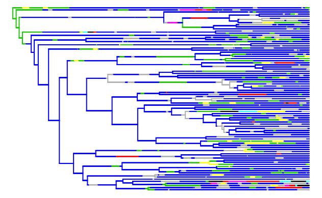

```r
plot(L2.maps$head[[1]], pts=F,ftype="off")
```

# References

Sharkey, Michael J, James M Carpenter, Lars Vilhelmsen, John Heraty, Johan Liljeblad, Ashley PG Dowling, Susanne Schulmeister, et al. 2012. “Phylogenetic Relationships Among Superfamilies of Hymenoptera.” *Cladistics* 28 (1). Wiley Online Library: 80–112.